```python
# Copyright (c) 2017, Gerti Tuzi
# All rights reserved.
#
# Redistribution and use in source and binary forms, with or without
# modification, are permitted provided that the following conditions are met:
#     * Redistributions of source code must retain the above copyright
#       notice, this list of conditions and the following disclaimer.
#     * Redistributions in binary form must reproduce the above copyright
#       notice, this list of conditions and the following disclaimer in the
#       documentation and/or other materials provided with the distribution.
#     * Neither the name of Gerti Tuzi nor the
#       names of its contributors may be used to endorse or promote products
#       derived from this software without specific prior written permission.
#
# THIS SOFTWARE IS PROVIDED BY THE COPYRIGHT HOLDERS AND CONTRIBUTORS "AS IS" AND
# ANY EXPRESS OR IMPLIED WARRANTIES, INCLUDING, BUT NOT LIMITED TO, THE IMPLIED
# WARRANTIES OF MERCHANTABILITY AND FITNESS FOR A PARTICULAR PURPOSE ARE
# DISCLAIMED. IN NO EVENT SHALL <COPYRIGHT HOLDER> BE LIABLE FOR ANY
# DIRECT, INDIRECT, INCIDENTAL, SPECIAL, EXEMPLARY, OR CONSEQUENTIAL DAMAGES
# (INCLUDING, BUT NOT LIMITED TO, PROCUREMENT OF SUBSTITUTE GOODS OR SERVICES;
# LOSS OF USE, DATA, OR PROFITS; OR BUSINESS INTERRUPTION) HOWEVER CAUSED AND
# ON ANY THEORY OF LIABILITY, WHETHER IN CONTRACT, STRICT LIABILITY, OR TORT
# (INCLUDING NEGLIGENCE OR OTHERWISE) ARISING IN ANY WAY OUT OF THE USE OF THIS
# SOFTWARE, EVEN IF ADVISED OF THE POSSIBILITY OF SUCH DAMAGE.
```

# Vehicle Detection and Tracking

## HOG Features

```python
import numpy as np
import cv2
import glob
import matplotlib.pyplot as plt
%matplotlib inline
```

Load a small dataset, for data exploration

```python
images = glob.glob('small_set/*.jpeg')
cars = []
notcars = []

for image in images:
    if 'image' in image or 'extra' in image:
        notcars.append(image)
    else:
        cars.append(image)
```

## HOG Parameter Selection

#### Pixels per cell

Qualititavely, it is desired to capture as much as possible the shape information of the object using gradient orientations.

With too small of a cell-size HOGs features bring out the small shapes. While with large cell sizes "macro" shapes are captured. A cell size of (8x8) pixels tends to balance well the "macro" & "micro" shape charateristics of the vehicle.

A cell of (4x4) pixels captures too many little details and loses the "macro" vehicular shape. Also when comparing to larger size cells the midlevel shapes (tires etc) tend to get lost. With larger cell-sizes, only the 3 dominating lines (when vehicle is viewed from behind) are left: ceiling, trunk, and bottom. This causes the classifier to also recognize lines, such as lanes, as valid objects, thus increasing the FP rate.

*So a certain level of spatial context is needed*. But this context cannot be too narrow, or we loose the macro shape data.

By visual inspection of different color domains, it seems that the YCrCb & YUV color scale seems to retain similar outlines of the vehicle. Also, by quantitavely experimenting with the SVM classifier across the different color scales, the classifier performs best on YCrCb & YUV, when trained/tested on the small set.

Below I'm comparing between cell sizes of (4x4) with (8x8).

#### Cells per block

Small cell blocks such that they are not too insesitive to light variations. This is why I selected a (2x2) block size

### Implementation:

Hog feature extraction is implemented in `utils.get_hog_features()`, lines: 380-392

[output not shown]

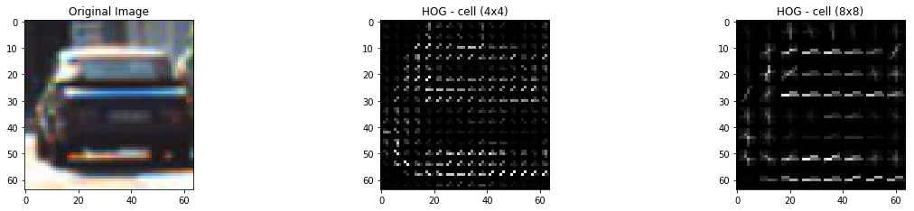

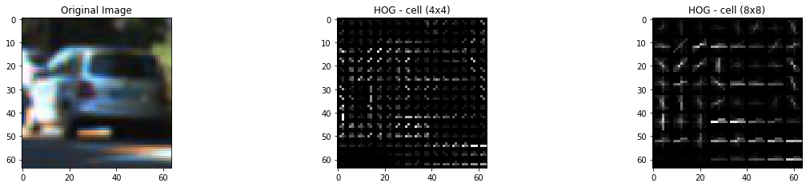

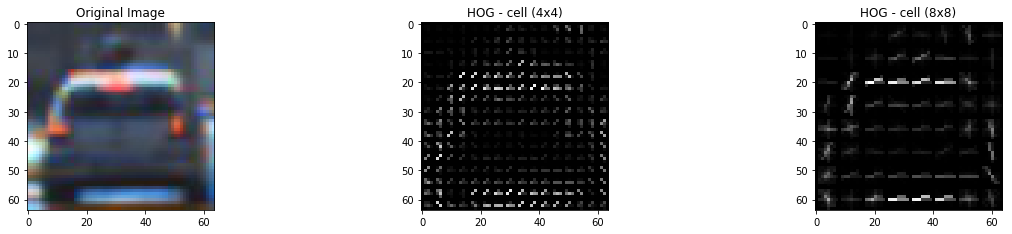

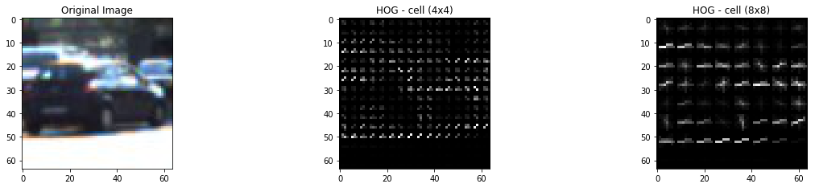

```python
from utils import get_hog_features

# HOG feature parameters to tweak
# Color space can be RGB, HSV, LUV, HLS, YUV, YCrCb
orient = 12  # HOG orientations
cell_per_block = int(2) # HOG cells per block : local area over which the histogram counts in a given cell will be normalized
hog_channel = 'ALL' # Can be 0, 1, 2, or "ALL"


# Load a few car images
p = 0
for i in range(0, 20, 5):

    img = cv2.imread(cars[i])

    # Visualize the avg HOG
    imgYUV = cv2.cvtColor(img, cv2.COLOR_BGR2YUV)
    avg_hog = np.zeros_like(img)
    hog_imgs = np.zeros(shape = (3,) + img.shape[0:2], dtype=np.float64)

    _, h_image_4 = get_hog_features(imgYUV[:, :, 0], orient, 4,
                                        cell_per_block, vis=True, feature_vec=False)

    _, h_image_8 = get_hog_features(imgYUV[:, :, 0], orient, 8,
                                        cell_per_block, vis=True, feature_vec=False)

    plt.figure(figsize=(20, 20))
    p +=1
    plt.subplot(5, 3,p)
    plt.imshow(cv2.cvtColor(img, cv2.COLOR_BGR2RGB))
    plt.title('Original Image')

    p += 1
    plt.subplot(5, 3,p)
    plt.imshow(h_image_4, cmap='gray')
    plt.title('HOG - cell (4x4)')

    p += 1
    plt.subplot(5, 3,p)
    plt.imshow(h_image_8, cmap='gray')
    plt.title('HOG - cell (8x8)')
```

## Data

Links to the labeled data for [vehicle](https://s3.amazonaws.com/udacity-sdc/Vehicle_Tracking/vehicles.zip) and [non-vehicle](https://s3.amazonaws.com/udacity-sdc/Vehicle_Tracking/non-vehicles.zip).

There are 8792 cars and 8968 non-cars (background). The data is fairly well balanced.

Shown below there is an example of a car image as well as a negative image.

```
Number of cars: 8792
Number of non-cars: 8968
```

[figure not shown]

```python
# Load training data

cars = glob.glob('vehicles/*/*.png', recursive=True)
notcars = glob.glob('non-vehicles/*/*.png', recursive=True)

print('Number of cars: {0}'.format(len(cars)))
print('Number of non-cars: {0}'.format(len(notcars)))

cTrainImg = cv2.imread(cars[100])
ncTrainImg = cv2.imread(notcars[100])

plt.figure(figsize=(10, 10))
plt.subplot(1, 2, 1)
plt.imshow(cv2.cvtColor(cTrainImg, cv2.COLOR_BGR2RGB))
plt.title('Sample Car')

plt.subplot(1, 2, 2)
plt.imshow(cv2.cvtColor(ncTrainImg, cv2.COLOR_BGR2RGB))
plt.title('Sample Negative')
```

#### Feature extraction pipeline

Feature extraction is encapsulated due to the lengthy time it takes to generate the entire set of data

```python
from utils import extract_features

# Exctract features
def extract_features_pipeline(cars, notcars, params):
    """
    Function to extract features from location of traning images
    :param cars: list of car locations
    :param notcars: list of non-car locations
    :param params: feature params
    :return:
    car_feats, non_car_feats
    """

    print('Preparing features ....')
    #
    car_features = extract_features(cars, color_space=params['color_space'],
                                    spatial_size=params['spatial_size'],
                                    hist_bins=params['hist_bins'],
                                    orient=params['orient'],
                                    pix_per_cell=params['pix_per_cell'],
                                    cell_per_block=params['cell_per_block'],
                                    hog_channel=params['hog_channel'],
                                    feats2gen=params['feats2gen'],
                                    norm=params['norm'])

    notcar_features = extract_features(notcars, color_space=params['color_space'],
                                    spatial_size=params['spatial_size'],
                                    hist_bins=params['hist_bins'],
                                    orient=params['orient'],
                                    pix_per_cell=params['pix_per_cell'],
                                    cell_per_block=params['cell_per_block'],
                                    hog_channel=params['hog_channel'],
                                    feats2gen=params['feats2gen'],
                                    norm=params['norm'])


    return car_features, notcar_features
```

## Training a Classifier (SVM)

## Image Pre-processing

- Pre-normalization: Images are first normalized using Contrast Limiting Adaptive Contrast Normalization (CLAHE) for light invariance. Here, the BGR image - as read by cv2.imread() - is first put into LAB color space. Next, CLAHE is applied to the L channel. Method is similar to [Link](https://www.mathworks.com/help/images/ref/adapthisteq.html). A significant drop in FPs was noticed using this normalization step. *implemented in: `utils.CLAHENormalize()`, lines: 44-49*).
- Color space: After manual experimentation on a small set, classification performance improved for images in YUV & YCrCb space. Note that **Color space was used AFTER pre-normalization using CLAHE**

## Features

### Features Parameters

For training 3 features were used:

- Image histograms along each color channel. Each image channel's histogram had 12 bins. I noticed that increasing the bins beyond this point doesn't give much improvement (*Histogram feature generation implemented in: `utils.imghist()`, lines: 178-191*)
- Spatial color features: this is simply a resized image - down from 64x64 to 16x16, then flattened, where the pixels of the image form the features. Images were reduced to save on performance. (*Implemented in `utils.bin_spatial()`, lines: 203-207*)
- HOG features **also see the discussion of HOG parameters above**: By manual inspection of several parameters - the following were deemed appropriate: 12 orientations, 8 pix / cell, 2 cells / block. HOG features were generated for all 3 channels of the YUV space. (*Implementation: `utils.get_hog_features()` lines: 379-391*)
- Feature normalization: features are normalized using the [`StandardScaler`](http://scikit-learn.org/stable/modules/generated/sklearn.preprocessing.StandardScaler.html), which standardize features by removing the mean and scaling to unit variance

```python
# Feature generation parameters
params= {'norm': True,
         'color_space':'YUV',       # Can be RGB, HSV, LUV, HLS, YUV, YCrCb
         'orient': 12,              # HOG orientations
         'pix_per_cell': int(8),    # HOG pixels per cell
         'cell_per_block': int(2),  # HOG cells per block : local area over which the
                                    # histogram counts in a given cell will be normalized
         'hog_channel': 'ALL',      # Can be 0, 1, 2, or "ALL"
         'spatial_size': (16, 16),  # Spatial binning dimensions
         'hist_bins': 12,           # Number of histogram bins
         'feats2gen': ['hist', 'hog', 'bin_spat'], # Feature operations / feautures to generate:
                                                    # ['hist', 'hog', 'bin_spat']
        }
```

```python
# Data location
cars = glob.glob('vehicles/*/*.png', recursive=True)
notcars = glob.glob('non-vehicles/*/*.png', recursive=True)


# Extract features once. Very time consuming to generate
car_features, notcar_features = extract_features_pipeline(cars, notcars, params)

print('Features extraction completed !!')
```

```python
import pickle
data2save = {'car_features': car_features, 'notcar_features':notcar_features}
with open('data_feats.p', 'wb') as f:
    pickle.dump(data2save, f, 2)
```

```python
import pickle
with open('data_feats.p', 'rb') as f:
    data2read = pickle.load(f)
    car_features = data2read['car_features']
    notcar_features = data2read['notcar_features']
```

## Classification

A linear SVM is used in this project. An optimized hyper-parameter search is desired, but it is very time consuming (see commented out code for that implementation).

A threshold of 1e-3 for the cost function was chosen to avoid over-fitting. This is a guess, and not a proper way to do this. It would be better to include this parameter in the hyper-parameter search (time consuming).

After training completion, the classifier and the normalizer are returned. These two objects are used for testing images.

### Training

Data is shuffled before training. The training process is implemented in `train_SVM()`.

```python
import math
import time
from sklearn.svm import LinearSVC, SVC
from sklearn.metrics import f1_score
from sklearn.preprocessing import StandardScaler
from sklearn.model_selection import train_test_split
from sklearn.model_selection import GridSearchCV
from sklearn.utils import shuffle

def train_SVM(car_features, notcar_features, params):

    """
    Training pipeline for a SVM
    :param car_features: car features
    :param notcar_features: not car features
    :return:
    classifier, scaler
    """

    # HOG: YCrCb,
    # hist: YCrCb/YUV
    # bin_spat: YUV

    X = np.vstack((car_features, notcar_features)).astype(np.float64)
    # Fit a per-column scaler
    X_scaler = StandardScaler().fit(X)
    # Apply the scaler to X
    scaled_X = X_scaler.transform(X)

    # Define the labels vector
    y = np.hstack((np.ones(len(car_features)), np.zeros(len(notcar_features))))

    # Quick shuffle
    rand_state = np.random.randint(0, 500)
    scaled_X, y = shuffle(scaled_X, y, random_state=rand_state)


    ################## Evaluation .... Optional #########################
    # Training Evaluation ... do the training parameters make sense ?
    # Split up data into randomized training and test sets
    rand_state = np.random.randint(0, 500)
    X_train, X_test, y_train, y_test = train_test_split(scaled_X, y, test_size=0.4, random_state=rand_state)

    print('Using:', params['orient'], 'orientations', params['pix_per_cell'],
          'pixels per cell and', params['cell_per_block'], 'cells per block')
    print('Feature vector length:', len(X_train[0]))



    # Perform best parameter search : time consuming
    # From the training data, extract a validation set for hyperparameters
#     X_train, X_valid, y_train, y_valid = train_test_split(X_train, y_train, test_size=0.3)

#     print('Hyperparameter search ......')
#     param_grid = {'kernel': ('linear', 'rbf'),
#                   'C': [0.005, 0.01, 0.05, 0.1, 0.5, 1, 5],
#                   'gamma': [math.pow(2, -5),math.pow(2, -4),
#                             math.pow(2, -3),math.pow(2, -2),
#                             math.pow(2, -1),math.pow(2, 0),
#                             math.pow(2, 1)]
#                   }
#     svr = SVC()
#     clf = GridSearchCV(svr, param_grid, verbose=1, n_jobs= -1)
#     clf.fit(X_valid, y_valid)

#     print('Training SVM classifier:' +
#           'C = {0}, gamma = {1}, kernel = {2}'.format(clf.best_params_['C'],
#                                                       clf.best_params_['gamma'],
#                                                       clf.best_params_['kernel']))

#     rand_state = np.random.randint(0, 500)
#     svc = SVC(tol=1e-4, max_iter=10000, verbose=True,
#               C= clf.best_params_['C'],
#               kernel=clf.best_params_['kernel'],
#               gamma=clf.best_params_['gamma'],
#               random_state=rand_state,
#               decision_function_shape='ovr')

    # Use a linear SVC
    svc = LinearSVC(tol=1e-3, max_iter=5000, verbose=1)

    # Check the training time for the Evaluation SVC
    t = time.time()
    svc.fit(X_train, y_train)
    t2 = time.time()
    print(round(t2 - t, 2), 'Seconds to train Evaluation-SVC...')

    # Check the score of the SVC
    print('Test Accuracy of Evaluation SVC = ', round(svc.score(X_test, y_test), 4))
    y_pred = svc.predict(X_test)
    f1_sc = f1_score(y_test, y_pred)
    print('Test F1 score of Evaluation SVC = ', round(f1_sc, 4))


    # Train with the final SVM: use all the data
    print('Training final SVC ...')
    t = time.time()
    svc = LinearSVC(tol=1e-3, max_iter=10000, verbose=1)
    svc.fit(scaled_X, y)
    t2 = time.time()
    print(round(t2 - t, 2), 'Seconds to train Final SVC...')


    return svc, X_scaler
```

```python
# Train classifier
svc, X_scaler = train_SVM(car_features, notcar_features, params)

data2save = {'svc': svc, 'X_scaler':X_scaler}
with open('svc.p', 'wb') as f:
    pickle.dump(data2save, f, 2)
```

```
Using: 12 orientations 8 pixels per cell and 2 cells per block
Feature vector length: 7860
[LibLinear]2.57 Seconds to train Evaluation-SVC...
Test Accuracy of Evaluation SVC =  0.9903
Test F1 score of Evaluation SVC =  0.9902
Training final SVC ...
[LibLinear]5.97 Seconds to train Final SVC...
```

```python
# Read pre-trained classifier
with open('svc.p', 'rb') as f:
    data2read = pickle.load(f)
    svc = data2read['svc']
    X_scaler = data2read['X_scaler']
```

## Sliding Window

Assumptions:

- Smaller vehicles are located farther from the vehicles and they appear more at the vanishinp point vertical position.
- Closer vehicles occupy larger pixel space.
- Closer vehicles occupy the y-dimension starting from the vanishing point level to the bottom of the image

### Sliding Scanning Window Algorithm

A number of window scales are chosen (5 for processing speed). The y-range between vanishing point - or middle of the height - and the bottom part of the image is divided into horizontal *search bands*. The search band defines the y-dimension search limits.

For each scale, the search band is the summation of individual search bands along the vertical dimension (*refer to figure below*). The window is smaller than the given search band.

[figure not shown]

Within each search band, the window slides by a given number of cells (as defined in the HOG features, where each cell is comprised of a set of pixels).

#### Search window size

The search starts with a scaled-down version of the search window (from the training window). This should increase perfromance of far away objects. It was noticed that this performance is not that good. This scaling should be performed on the training data (as data augmentation) to see how it performs. The same holds true for scaling up the image.

#### Heat-Map

To merge search results of the scanning window, the heat-map approach is used. For each positive result from the classifier, respective pixel hit-counts are incremented. Thus, for multiple positive windows, some pixels will have a higher hit count than others. This is viewed as a "hot" value, resulting in heat map, when viewed from the image perspective. So, for every image, there is a corresponding heat map of same size.

To reduce the FP rate, the heatmap is thresholded, whereby only pixels of a certain value (threshold) are deemed as belonging to a positive object.

### Implementation

The search band method is shown below (`search_objects()`)

```python
from utils import find_objects

def search_objects(svc, X_scaler, params, test_image):

    img_max_y = test_image.shape[0]
    y_start_stop = [350, img_max_y]  # Min and max in y to search in slide_window()

    n_search_bands = 5
    y_search_band = (y_start_stop[1] - y_start_stop[0] + 1) / n_search_bands
    train_window_size = (int(64), int(64))

    box_list = []
    i = 0
    for scale in np.linspace(0.8, 1.6, num=n_search_bands):
        i += 1
        y_start = y_start_stop[0]

        # Define the lower boundary of the horizontal search band
        y_stop = int((np.ceil(y_start + i * y_search_band)))

        # Clip to no lower than the max y of the image
        y_stop = np.min([y_stop, img_max_y])

        # Scan for objects in this search band
        _, boxes = find_objects(test_image, y_start, y_stop,
                                scale, svc, params['color_space'],
                                X_scaler, params['orient'], params['pix_per_cell'],
                                window=train_window_size, cells_per_step=2,
                                cell_per_block=params['cell_per_block'],
                                spatial_size=params['spatial_size'],
                                hist_bins=params['hist_bins'],
                                feats2gen=params['feats2gen'],
                                retlabels=True,
                                norm=params['norm'])

        box_list.extend(boxes)

    return box_list
```

### Test Classifier on Test Images

Using sample images from the video

[output not shown]

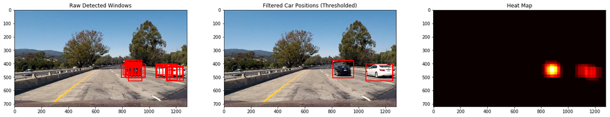

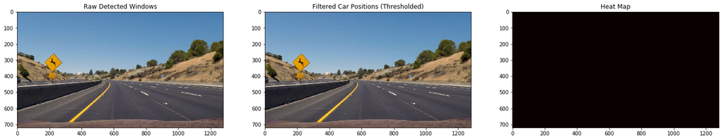

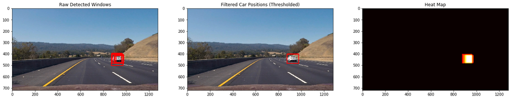

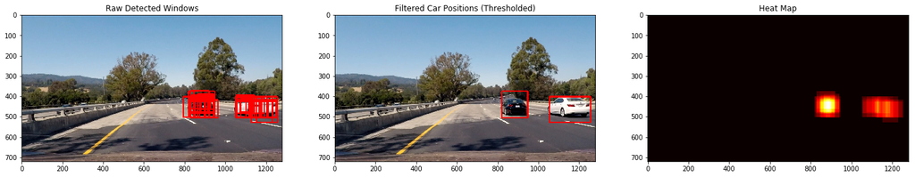

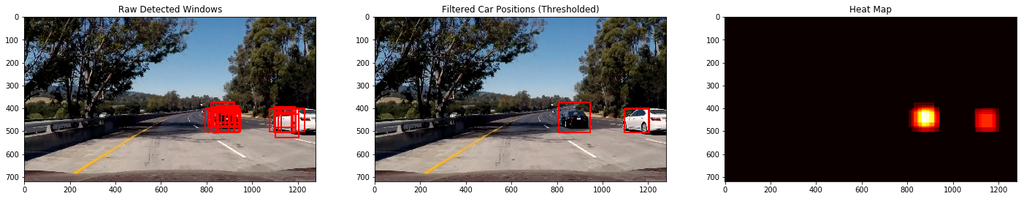

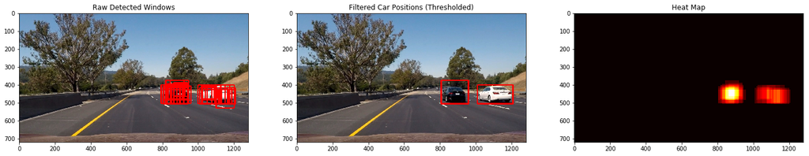

```python
from scipy.ndimage.measurements import label
from utils import add_heat, apply_threshold, draw_boxes, draw_labeled_bboxes

testimages = glob.glob('test_images/*.jpg')

fig = plt.figure()
p = 0

# Loop over test images
for t in range(0, 6):
    timg = cv2.imread(testimages[t])

    box_list = search_objects(svc, X_scaler, params, test_image=timg)

    # Read in image similar to one shown above
    heat = np.zeros_like(timg[:,:,0]).astype(np.float)

    # Add heat to each box in box list
    heat = add_heat(heat, box_list)

    # Apply threshold to help remove false positives
    heat = apply_threshold(heat, 1)

    # Visualize the heatmap when displaying
    heatmap = np.clip(heat, 0, 255)

    # Find final boxes from heatmap using label function
    labels = label(heatmap)
    window_img = draw_boxes(np.copy(timg), box_list)
    draw_img = draw_labeled_bboxes(np.copy(timg), labels)


    plt.figure(figsize=(20, 20))
    p +=1
    plt.subplot(6, 3, p)
    plt.imshow(cv2.cvtColor(window_img, cv2.COLOR_BGR2RGB))
    plt.title('Raw Detected Windows')
    p += 1
    plt.subplot(6, 3,p)
    plt.imshow(cv2.cvtColor(draw_img, cv2.COLOR_BGR2RGB))
    plt.title('Filtered Car Positions (Thresholded)')
    p += 1
    plt.subplot(6, 3,p)
    plt.imshow(heatmap, cmap='hot')
    plt.title('Heat Map')

    plt.tight_layout(pad=0.1, w_pad=0.1, h_pad=0.1)
```

# Video Test

The video pipeline implements a buffered heat map.

The buffer maintains a FIFO que of heatmaps. The thresholded map is generated on the summation of the queue at a given time.

Buffer size is 5, and threshold heatmap value is also 5 (pixels with heat count of 5 or less, are zeroed out).

Video is processed and a new video is output with the detections drawn on it.

```python
def process_video_pipeline(image, buffHM):

    """
    Process video input. A heat map buffer object is passed in and out
    :param image: image to process
    :param buffHM: buffer object
    :return:

    """

    box_list = search_objects(svc, X_scaler, params, test_image=image)

    # Add box list to buffered heat map
    buffHM.onBoxes(box_list)

    # Obtain thresholded heat map
    heatmap = buffHM.getThreshBuffHeatMap(thresh=5)

    # Visualize the heatmap when displaying
    heatmap = np.clip(heatmap, 0, 255)

    # Find final boxes from heatmap using label function
    labels = label(heatmap)

    # Draw bounding boxes after threshold
    filtered_results = draw_labeled_bboxes(np.copy(image), labels)

    # Draw raw boxes
    raw_results = draw_boxes(np.copy(image), box_list)

    return filtered_results, raw_results, buffHM
```

```python
# Processing the video
from BufferedHeatmap import BufferedHeatmap


vidfile = 'project_video.mp4'
imgshape = (720, 1280)
buffmap = BufferedHeatmap(imgshape)
vidcap = cv2.VideoCapture(vidfile)
vid_writer = cv2.VideoWriter('project_video_out.mp4', -1, 33.0, (int(1280 / 2), int(720 / 2)))
fps = vidcap.get(cv2.CAP_PROP_FPS)
success = True
i = 0
while vidcap.isOpened() and success:
    success,image = vidcap.read()
    i +=1
    print('Read a new frame: {0} - {1}'.format(i, success))
    if success:
        result, raw_results, buffmap = process_video_pipeline(image, buffmap)
        vid_writer.write(cv2.resize(result, (int(1280 / 2), int(720 / 2)), interpolation=cv2.INTER_AREA))

        plt.cla()
        plt.subplot(211)
        plt.imshow(cv2.cvtColor(raw_results, cv2.COLOR_BGR2RGB))
        plt.title('Raw Results')

        plt.subplot(212)
        plt.imshow(cv2.cvtColor(result, cv2.COLOR_BGR2RGB))
        plt.title('Filtered Results')
        plt.pause(0.000001)
```

```python
try:
    vid_writer.release()
except:
    pass
```

```python
import io
import base64
from IPython.display import HTML

video = io.open('project_video_out.mp4', 'r+b').read()
encoded = base64.b64encode(video)
HTML(data='''<video alt="project_video" width="640" height="360" controls>
                <source src="project_video_out.mp4" type="video/mp4" />
             </video>'''.format(encoded.decode('ascii')))
```

[video not shown]

## Discussion

- The small dataset is very misleading for manually chosing HOG feature parameters, when relying on classification performance metrics. With the small dataset, classification was very high on wide range of HOG cell sizes. It is necessary to use a larger set to choose the optimal HOG features. One can rely slightly on visual inspection for choosing optimal cell-size, but this is still very un-reliable as a guide. The cell sizes of 8x8 were finally settled on after training the classifier with the large dataset. But this approach is still, suboptimal, since the test-result is in this case, a validation and does not say anything about generalization. Again, more video sequences are needed.
- Image contrast normalization reduces significantly false positives.
- Data augmentation by varying scales, could be performed to introduce scale variances.
- The buffer threshold of 5 is more robust to supurious noise, but it causes the filter to slowly box the vehicle size. Weighted buffer should be better. Decay the heat contribution weight for older frames. This should generate a faster responding filter.
- A tracking algorithm should be placed to further reduce the false positives.
- A more analytic approach shoud be taken for tuning filter parameters. Several validation videos should be tuned (after all, this is still hyper-parameter tuning)
- HOG features when applied to vehicles pick up on the line contours. However this is fairly similar to lane contours as well, and is the source of a slight increase of FPs. Perhaps a confidence output (probability measure) could be used with the heat map, instead of +1 increments (future work).
- Future work: Hyper-parameter search should be implemented, though very time-consuming. I don't have a good sense if this classifier is trained properly with respect to over/underfitting.